# Tugas Pendahuluan Praktikum Dasar Kecerdasan Artifisial

### Modul 4 : Pengantar Dasar NetworkX

*INSTALLASI LIBRARY MK DKA*  
Jika belum terinstal, jalankan perintah berikut pada terminal atau notebook:

```
pip install jupyter ipykernel numpy matplotlib networkx sympy scikit-fuzzy scipy
```

## Petunjuk Umum

1. **Jangan ubah struktur kode yang diberikan, cukup isi bagian yang kosong.**
2. **Jalankan setiap sel satu per satu agar tidak ada error.**
3. **Gunakan modul praktikum atau dokumentasi NetworkX (`https://networkx.org/documentation/stable/`) jika membutuhkan referensi tambahan.**
4. **Kerjakan soal yang ada secara berurutan, dikarenakan soal akan meneruskan code soal sebelumnya**

```python
print("Muhammad Alvin Faaa'iz")  # Tuliskan nama lengkap Anda
print("103012400229")  # Tuliskan NIM Anda
print("IF-48-11")  # Tuliskan kelas Anda
print("VVN") # Tuliskan kode asprak anda
```

```
Muhammad Alvin Faaa'iz
103012400229
IF-48-11
VVN
```

## Pengenalan NetworkX

NetworkX adalah pustaka Python yang digunakan untuk bekerja dengan **graf dan jaringan**.  
Dengan NetworkX, kita dapat membuat **struktur graf**, menambahkan **simpul (nodes)** dan **sisi (edges)**, serta melakukan berbagai **analisis graf**.

Sebelum memulai, pastikan Anda telah mengimpor pustaka berikut:

```python
import networkx as nx # Import library NetworkX
import matplotlib.pyplot as plt # Import library Matplotlib
```

## Soal 1: Membuat dan Menampilkan Graf Sederhana

1. **Buat sebuah graf kosong** menggunakan **NetworkX**.
2. **Tambahkan simpul (node)** "A", "B", "C", dan "D".
3. **Tambahkan sisi (edge)** antara:
   - "A" dan "B"
   - "A" dan "C"
   - "B" dan "D"
   - "C" dan "D"
4. **Tampilkan graf yang telah dibuat** dengan `nx.draw()`.

💡 *Clue:* Gunakan fungsi `add_node()`, `add_nodes_from()`, `add_edge()`, dan `add_edges_from()`.  
Jangan lupa menampilkan graf dengan `plt.show()`.  
Isi bagian kosong di bawah ini:

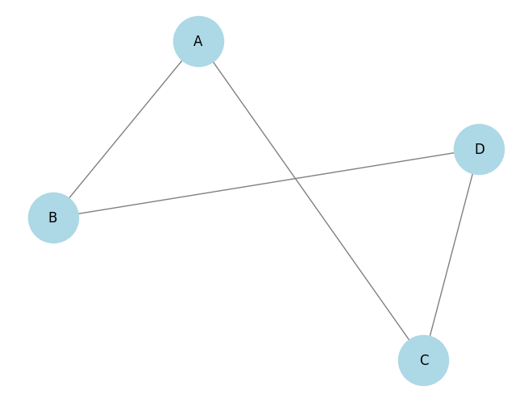

```python
G = nx.Graph()  # Buat graf kosong

# Tambahkan simpul (node)
G.add_node("A")  # Tambahkan satu simpul
G.add_nodes_from(["B", "C", "D"])  # Tambahkan beberapa simpul sekaligus

# Tambahkan sisi (edge)
G.add_edge("A", "B")  # Tambahkan satu sisi
G.add_edges_from([("A", "C"), ("B", "D"), ("C", "D")])  # Tambahkan beberapa sisi sekaligus

# Tampilkan graf
nx.draw(G, with_labels=True, node_color="lightblue", edge_color="gray", node_size=2000, font_size=12)
plt.show()
```

Contoh *output*:

[figure not shown]

## Soal 2: Memodifikasi Graf

1. **Tambahkan simpul baru** bernama **"E"** ke dalam graf.
2. **Hubungkan simpul "E"** ke "A" dan "D".
3. **Tampilkan kembali graf yang telah diperbarui**.

Isi bagian kosong di bawah ini:

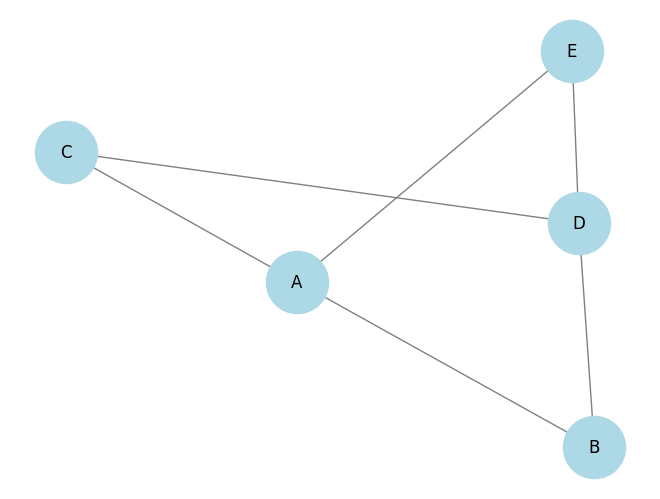

```python
# Soal 2: Menambahkan simpul dan sisi baru
G.add_node("E")  # Tambahkan simpul E
G.add_edges_from([("E", "A"), ("E", "D")])  # Hubungkan E ke A dan D

# Tampilkan graf yang diperbarui
nx.draw(G, with_labels=True, node_color="lightblue", edge_color="gray", node_size=2000, font_size=12)
plt.show()
```

Contoh *output*:

[figure not shown]

## Soal 3: Membuat Graf Baru dengan 5 Simpul dan 6 Sisi

1. **Buat graf baru** yang berisi 5 simpul bernama **X, Y, Z, W, V**.
2. **Tambahkan 6 sisi** sesuai kebutuhan.
3. **Tampilkan graf dengan warna berbeda untuk simpul dan sisi**.

💡 *Clue:* Gunakan warna berbeda di `nx.draw()` seperti:

- `node_color="pink"` untuk simpul berwarna merah muda
- `edge_color="blue"` untuk sisi berwarna biru

Isi bagian kosong di bawah ini:

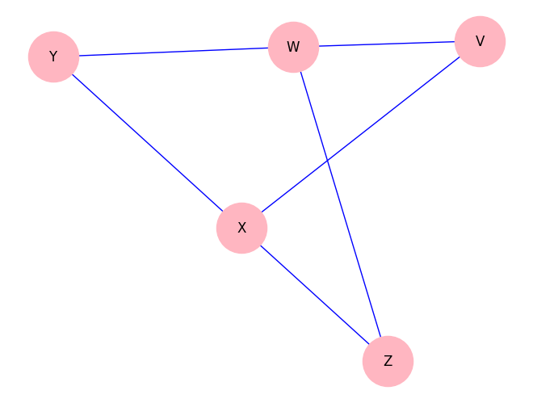

```python
# Soal 3: Membuat graf baru
H = nx.Graph()  # Buat graf baru

# Tambahkan 5 simpul
H.add_nodes_from(["X", "Y", "Z", "W", "V"])

# Tambahkan 6 sisi
H.add_edges_from([("Y", "X"), ("Y", "W"), ("W", "Z"), ("W", "V"), ("X", "Z"), ("X", "V")])

# Tampilkan graf dengan warna berbeda dan sesuaikan dengan parameter yang dibutuhkan
nx.draw(H, with_labels=True, node_color="lightpink", edge_color="blue", node_size=2000, font_size=12)
plt.show()
```

Contoh *output*:

[figure not shown]